# BTS 510 Lab 13

```r
library(tidyverse)
library(kableExtra)
set.seed(12345)
theme_set(theme_classic(base_size = 16))
```

## 1 Learning objectives

- *Describe* the logic of factorial ANOVA
  - Including main effects and interactions
- *Conduct* and *interpret* the factorial ANOVA tests
- *Conduct* post hoc tests for the factorial ANOVA

## 2 Data

- `birthwt` dataset in the **MASS** package
  - `race`: mother’s race (1 = white, 2 = black, 3 = other).
  - `smoke`: smoking status during pregnancy.
  - `bwt`: birth weight in grams
- Convert both `race` and `smoke` to factor variables using `mutate()` and `as.factor()`

```r
library(MASS)
data(birthwt)
birthwt <- birthwt %>%
  mutate(race = as.factor(race),
         smoke = as.factor(smoke))
head(birthwt)
```

```
   low age lwt race smoke ptl ht ui ftv  bwt
85   0  19 182    2     0   0  0  1   0 2523
86   0  33 155    3     0   0  0  0   3 2551
87   0  20 105    1     1   0  0  0   1 2557
88   0  21 108    1     1   0  0  1   2 2594
89   0  18 107    1     1   0  0  1   0 2600
91   0  21 124    3     0   0  0  0   0 2622
```

### 2.1 Research question

- How are mother’s race and mother’s smoking status related to the birth weight of a baby?

### 2.2 Means

- Means by `race` and `smoke`

```r
bwt_sum <- birthwt %>%
  group_by(race, smoke) %>%
  summarize(nbwt = length(bwt),
            meanbwt = mean(bwt),
            sdbwt = sd(bwt))
kable(bwt_sum)
```

| race | smoke | nbwt | meanbwt | sdbwt |
| --- | --- | --- | --- | --- |
| 1 | 0 | 44 | 3428.750 | 710.0989 |
| 1 | 1 | 52 | 2826.846 | 626.4725 |
| 2 | 0 | 16 | 2854.500 | 621.2543 |
| 2 | 1 | 10 | 2504.000 | 637.0568 |
| 3 | 0 | 55 | 2815.782 | 709.3493 |
| 3 | 1 | 12 | 2757.167 | 810.0446 |

- Plot of means

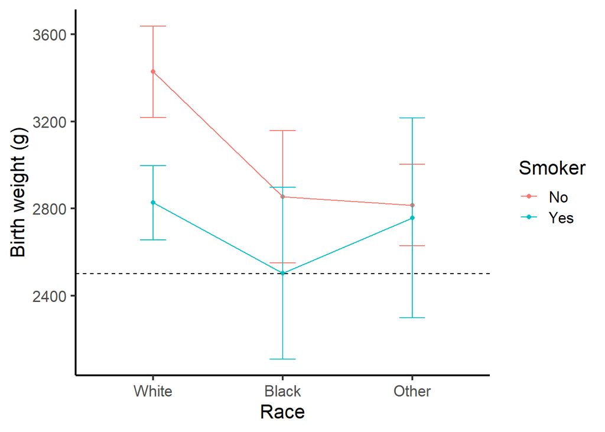

```r
ggplot(data = bwt_sum,
       aes(x = race,
           y = meanbwt,
           group = smoke,
           color = smoke)) +
  geom_point() +
  geom_path(aes(group = smoke)) +
  geom_errorbar(aes(ymin = meanbwt - 1.96*sdbwt/sqrt(nbwt),
                    ymax = meanbwt + 1.96*sdbwt/sqrt(nbwt)),
                width = 0.2) +
  labs(x = "Race",
       y = "Birth weight (g)") +
  scale_x_discrete(labels=c("1" = "White",
                            "2" = "Black",
                            "3" = "Other")) +
  scale_color_discrete(name = "Smoker",
                       labels = c("No", "Yes")) +
  geom_hline(yintercept = 2500, linetype = "dashed")
```

## 3 ANOVA

### 3.1 Assumptions: Equal variance

- Do all the groups (6 groups defined by `race` and `smoke`) have **equal variance** on the outcome variable (`bwt`)?

#### 3.1.1 Graphically

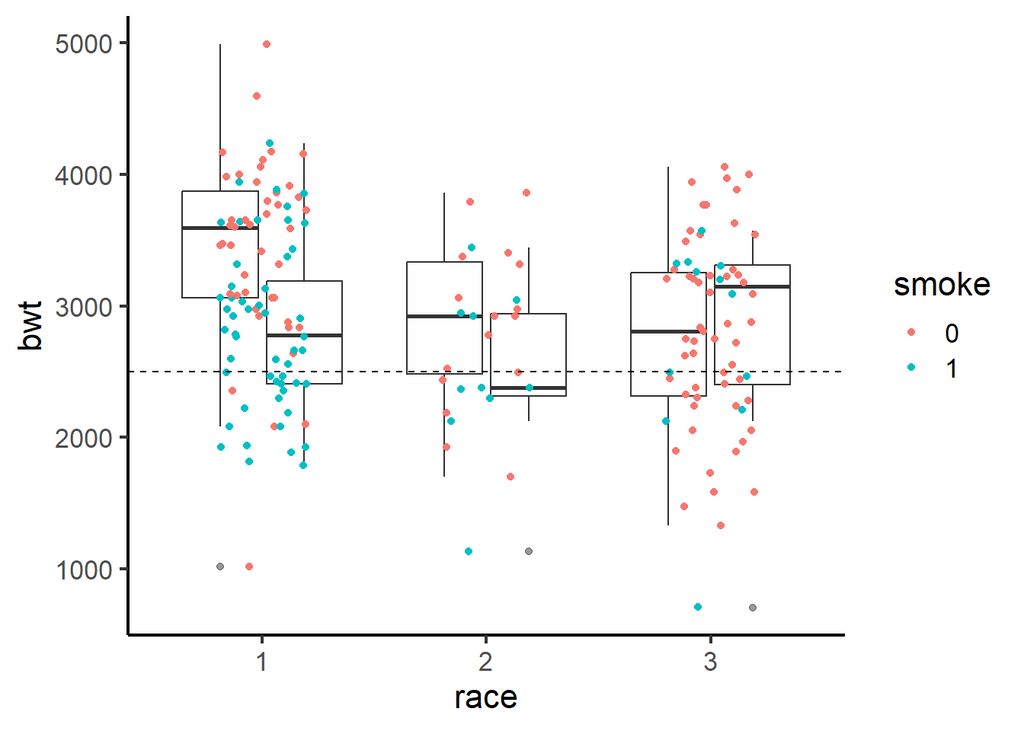

```r
ggplot(data = birthwt,
       aes(x = race,
           y = bwt,
           group = interaction(race, smoke))) +
  geom_boxplot(alpha = 0.5) +
  geom_jitter(width = 0.2, aes(color = smoke)) +
  geom_hline(yintercept = 2500, linetype = "dashed")
```

#### 3.1.2 Levene’s Test

- `leveneTest()` in **car** package
  - $H_0$: No differences in variances across groups
  - NS result = equal variances

```r
library(car)
leveneTest(bwt ~ race:smoke, data = birthwt)
```

```
Levene's Test for Homogeneity of Variance (center = median)
       Df F value Pr(>F)
group   5   0.345  0.885
      183
```

- The assumption of equal variances is met

### 3.2 ANOVA

- **Step 1**: `lm()` function for **linear model**
  - `outcome ~ predictors` format
  - Effects of `race`, `smoke`, and interaction (`race*smoke`)
  - Contrasts: Sum (`contr.sum`) in `list()` function to allow one for each factor
- **Step 2**: `Anova()` function in **car** package
  - Provide model (`m1` on last slide)
  - `type = 3` for correct type III sums of squares

```r
m1 <- lm(bwt ~ race + smoke + race*smoke,
         contrasts=list(race = contr.sum,
                        smoke = contr.sum),
         data = birthwt)

library(car)
Anova(m1, type = 3)
```

```
Anova Table (Type III tests)

Response: bwt
               Sum Sq  Df   F value    Pr(>F)
(Intercept) 965426089   1 2065.6367 < 2.2e-16 ***
race          5779165   2    6.1826  0.002522 **
smoke         3340683   1    7.1478  0.008185 **
race:smoke    2101808   2    2.2485  0.108463
Residuals    85529548 183
---
Signif. codes:  0 '***' 0.001 '**' 0.01 '*' 0.05 '.' 0.1 ' ' 1
```

### 3.3 Overall conclusions

- We **reject** the null hypothesis that all `race` means are equal, F(2, 183) = 6.18, p = .0025. **At least one `race` group mean is different from the others.**
- We **reject** the null hypothesis that all `smoke` means are equal, F(1, 183) = 7.15, p = .0082. **At least one `smoke` group mean is different from the others.**
- We **retain** the null hypothesis that there is **not** an interaction, F(2, 183) = 2.25, p = .1085. **There is no interaction of `race` and `smoke`.**
  - The effect of `race` doesn’t depend on `smoke`
  - The effect of `smoke` doesn’t depend on `race`

### 3.4 Assumptions: Normality

#### 3.4.1 Graphically

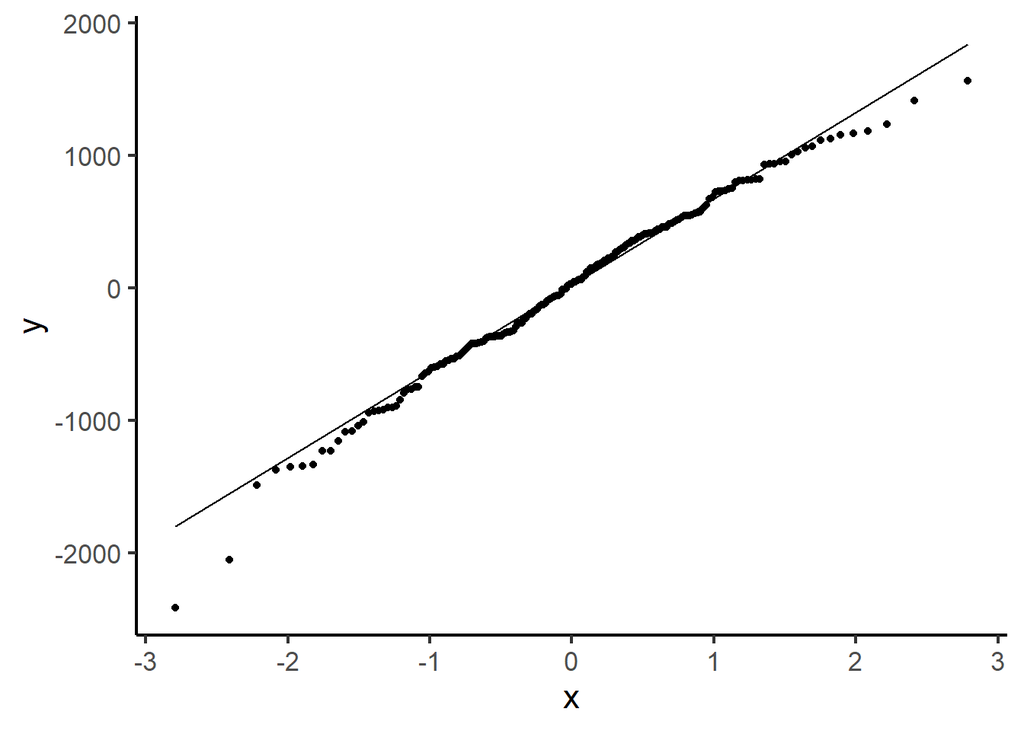

```r
m1resid <- data.frame(residuals(m1))
ggplot(data = m1resid,
       aes(sample = residuals.m1.)) +
  geom_qq() +
  geom_qq_line()
```

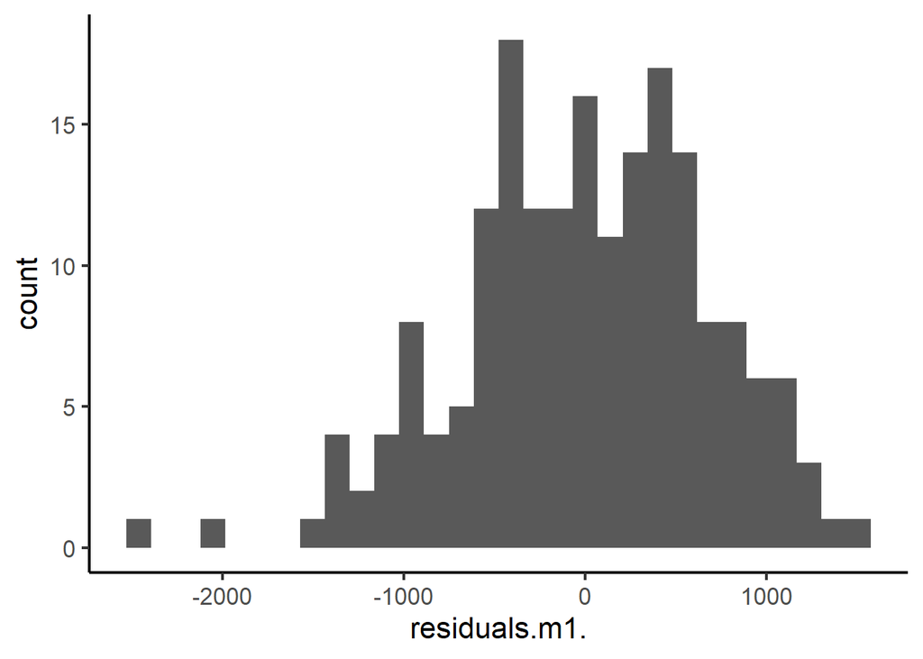

```r
m1resid <- data.frame(residuals(m1))
ggplot(data = m1resid,
       aes(x = residuals.m1.)) +
  geom_histogram()
```

#### 3.4.2 Shapiro-Wilk Test

- `shapiro.test()` in **stats**
  - $H_0$: Observations come from normally distributed population
  - NS result = normally distributed residuals

```r
shapiro.test(resid(m1))
```

```
    Shapiro-Wilk normality test

data:  resid(m1)
W = 0.98836, p-value = 0.1246
```

### 3.5 Post hoc tests

- `emmeans()` function in **emmeans** package
  - Provide model name (`m1`)
  - Type of contrast (`spec = trt.vs.ctrl` for 1st group as reference)
    - Other options: `pairwise`, `trt.vs.ctrlk` (last group as reference)
  - Factor you want contrasts for: here, only `race`
  - Adjustment for multiple comparisons: here, `"none"`
    - Other options: `tukey`, `bonf`, `fdr`
- Note that these are not the **raw means**
  - **Estimated marginal means** (emmeans): Model based

```r
library(emmeans)
emmeans(m1, spec = trt.vs.ctrl ~ race, adjust = "none")
```

```
NOTE: Results may be misleading due to involvement in interactions
```

```
$emmeans
 race emmean  SE  df lower.CL upper.CL
 1      3128  70 183     2990     3266
 2      2679 138 183     2407     2951
 3      2786 109 183     2572     3001

Results are averaged over the levels of: smoke
Confidence level used: 0.95

$contrasts
 contrast      estimate  SE  df t.ratio p.value
 race2 - race1     -449 155 183  -2.902  0.0042
 race3 - race1     -341 129 183  -2.636  0.0091

Results are averaged over the levels of: smoke
```

- What if we used a Bonferroni correction?

```r
emmeans(m1, spec = trt.vs.ctrl ~ race, adjust = "bonf")
```

```
NOTE: Results may be misleading due to involvement in interactions
```

```
$emmeans
 race emmean  SE  df lower.CL upper.CL
 1      3128  70 183     2990     3266
 2      2679 138 183     2407     2951
 3      2786 109 183     2572     3001

Results are averaged over the levels of: smoke
Confidence level used: 0.95

$contrasts
 contrast      estimate  SE  df t.ratio p.value
 race2 - race1     -449 155 183  -2.902  0.0083
 race3 - race1     -341 129 183  -2.636  0.0182

Results are averaged over the levels of: smoke
P value adjustment: bonferroni method for 2 tests
```

- What about using false discovery rate (FDR)?

```r
emmeans(m1, spec = trt.vs.ctrl ~ race, adjust = "fdr")
```

```
NOTE: Results may be misleading due to involvement in interactions
```

```
$emmeans
 race emmean  SE  df lower.CL upper.CL
 1      3128  70 183     2990     3266
 2      2679 138 183     2407     2951
 3      2786 109 183     2572     3001

Results are averaged over the levels of: smoke
Confidence level used: 0.95

$contrasts
 contrast      estimate  SE  df t.ratio p.value
 race2 - race1     -449 155 183  -2.902  0.0083
 race3 - race1     -341 129 183  -2.636  0.0091

Results are averaged over the levels of: smoke
P value adjustment: fdr method for 2 tests
```

- What if we wanted all possible pairwise comparisons?

```r
emmeans(m1, spec = pairwise ~ race, adjust = "none")
```

```
NOTE: Results may be misleading due to involvement in interactions
```

```
$emmeans
 race emmean  SE  df lower.CL upper.CL
 1      3128  70 183     2990     3266
 2      2679 138 183     2407     2951
 3      2786 109 183     2572     3001

Results are averaged over the levels of: smoke
Confidence level used: 0.95

$contrasts
 contrast      estimate  SE  df t.ratio p.value
 race1 - race2      449 155 183   2.902  0.0042
 race1 - race3      341 129 183   2.636  0.0091
 race2 - race3     -107 176 183  -0.610  0.5423

Results are averaged over the levels of: smoke
```

- What if we wanted all possible pairwise comparisons and also wanted to include `smoke` in this?

```r
emmeans(m1, spec = pairwise ~ race*smoke, adjust = "none")
```

```
$emmeans
 race smoke emmean    SE  df lower.CL upper.CL
 1    0       3429 103.1 183     3225     3632
 2    0       2854 170.9 183     2517     3192
 3    0       2816  92.2 183     2634     2998
 1    1       2827  94.8 183     2640     3014
 2    1       2504 216.2 183     2077     2931
 3    1       2757 197.4 183     2368     3147

Confidence level used: 0.95

$contrasts
 contrast                    estimate  SE  df t.ratio p.value
 race1 smoke0 - race2 smoke0    574.2 200 183   2.877  0.0045
 race1 smoke0 - race3 smoke0    613.0 138 183   4.433  <.0001
 race1 smoke0 - race1 smoke1    601.9 140 183   4.298  <.0001
 race1 smoke0 - race2 smoke1    924.8 239 183   3.861  0.0002
 race1 smoke0 - race3 smoke1    671.6 223 183   3.016  0.0029
 race2 smoke0 - race3 smoke0     38.7 194 183   0.199  0.8422
 race2 smoke0 - race1 smoke1     27.7 195 183   0.141  0.8876
 race2 smoke0 - race2 smoke1    350.5 276 183   1.272  0.2050
 race2 smoke0 - race3 smoke1     97.3 261 183   0.373  0.7097
 race3 smoke0 - race1 smoke1    -11.1 132 183  -0.084  0.9334
 race3 smoke0 - race2 smoke1    311.8 235 183   1.327  0.1863
 race3 smoke0 - race3 smoke1     58.6 218 183   0.269  0.7882
 race1 smoke1 - race2 smoke1    322.8 236 183   1.368  0.1731
 race1 smoke1 - race3 smoke1     69.7 219 183   0.318  0.7507
 race2 smoke1 - race3 smoke1   -253.2 293 183  -0.865  0.3882
```

- Wow, let’s throw a Bonferroni correction on that one…

```r
emmeans(m1, spec = pairwise ~ race*smoke, adjust = "bonf")
```

```
$emmeans
 race smoke emmean    SE  df lower.CL upper.CL
 1    0       3429 103.1 183     3225     3632
 2    0       2854 170.9 183     2517     3192
 3    0       2816  92.2 183     2634     2998
 1    1       2827  94.8 183     2640     3014
 2    1       2504 216.2 183     2077     2931
 3    1       2757 197.4 183     2368     3147

Confidence level used: 0.95

$contrasts
 contrast                    estimate  SE  df t.ratio p.value
 race1 smoke0 - race2 smoke0    574.2 200 183   2.877  0.0673
 race1 smoke0 - race3 smoke0    613.0 138 183   4.433  0.0002
 race1 smoke0 - race1 smoke1    601.9 140 183   4.298  0.0004
 race1 smoke0 - race2 smoke1    924.8 239 183   3.861  0.0023
 race1 smoke0 - race3 smoke1    671.6 223 183   3.016  0.0438
 race2 smoke0 - race3 smoke0     38.7 194 183   0.199  1.0000
 race2 smoke0 - race1 smoke1     27.7 195 183   0.141  1.0000
 race2 smoke0 - race2 smoke1    350.5 276 183   1.272  1.0000
 race2 smoke0 - race3 smoke1     97.3 261 183   0.373  1.0000
 race3 smoke0 - race1 smoke1    -11.1 132 183  -0.084  1.0000
 race3 smoke0 - race2 smoke1    311.8 235 183   1.327  1.0000
 race3 smoke0 - race3 smoke1     58.6 218 183   0.269  1.0000
 race1 smoke1 - race2 smoke1    322.8 236 183   1.368  1.0000
 race1 smoke1 - race3 smoke1     69.7 219 183   0.318  1.0000
 race2 smoke1 - race3 smoke1   -253.2 293 183  -0.865  1.0000

P value adjustment: bonferroni method for 15 tests
```

- What if we wanted to use the last group (“other”) as the reference?

```r
emmeans(m1, spec = trt.vs.ctrlk ~ race, adjust = "none")
```

```
NOTE: Results may be misleading due to involvement in interactions
```

```
$emmeans
 race emmean  SE  df lower.CL upper.CL
 1      3128  70 183     2990     3266
 2      2679 138 183     2407     2951
 3      2786 109 183     2572     3001

Results are averaged over the levels of: smoke
Confidence level used: 0.95

$contrasts
 contrast      estimate  SE  df t.ratio p.value
 race1 - race3      341 129 183   2.636  0.0091
 race2 - race3     -107 176 183  -0.610  0.5423

Results are averaged over the levels of: smoke
```

- Just for fun, let’s look at the `smoke` contrast, even though we don’t need to because there are only 2 levels
  - Remember that squaring the $t$ statistic here will give you the $F$ statistic from the ANOVA table

```r
emmeans(m1, spec = pairwise ~ smoke, adjust = "none")
```

```
NOTE: Results may be misleading due to involvement in interactions
```

```
$emmeans
 smoke emmean    SE  df lower.CL upper.CL
 0       3033  73.3 183     2888     3178
 1       2696 102.6 183     2494     2898

Results are averaged over the levels of: race
Confidence level used: 0.95

$contrasts
 contrast        estimate  SE  df t.ratio p.value
 smoke0 - smoke1      337 126 183   2.674  0.0082

Results are averaged over the levels of: race
```

## 4 How to do ANOVA wrong

- There are a LOT of ways to do the ANOVA wrong
  - The most obvious one is to use the `anova()` function
  - This gives type I sums of squares instead of the correct type III

```r
anova(m1)
```

```
Analysis of Variance Table

Response: bwt
            Df   Sum Sq Mean Sq F value   Pr(>F)
race         2  5015725 2507863  5.3659 0.005438 **
smoke        1  7322575 7322575 15.6675 0.000108 ***
race:smoke   2  2101808 1050904  2.2485 0.108463
Residuals  183 85529548  467375
---
Signif. codes:  0 '***' 0.001 '**' 0.01 '*' 0.05 '.' 0.1 ' ' 1
```

```r
library(car)
Anova(m1, type = 3)
```

```
Anova Table (Type III tests)

Response: bwt
               Sum Sq  Df   F value    Pr(>F)
(Intercept) 965426089   1 2065.6367 < 2.2e-16 ***
race          5779165   2    6.1826  0.002522 **
smoke         3340683   1    7.1478  0.008185 **
race:smoke    2101808   2    2.2485  0.108463
Residuals    85529548 183
---
Signif. codes:  0 '***' 0.001 '**' 0.01 '*' 0.05 '.' 0.1 ' ' 1
```

- What’s the same?
  - Degrees of freedom
  - Residual SS: That’s what’s left over after everything else
  - Sums of squares, etc. for interaction: More on that in a second
- What’s different?
  - Everything else

### 4.1 Why are they different?

- Type I SS *partials out* or holds constant **all effects entered before this effect**
  - **Order you enter effects matters**
  - Effect of race is partialling **nothing**
  - Effect of smoke is partialling **race only**
  - Effect of interaction is partialling **both race and smoke**
- Type III SS *partials out* or holds constant **all other effects**
  - **Order you enter effects doesn’t matter**
  - Effect of race is partialling **both smoke and the interaction**
  - Effect of smoke is partialling **both race and the interaction**
  - Effect of interaction is partialling **both race and smoke**

### 4.2 Change the predictor order

- Change the order of predictors: `smoke` then `race` then interaction

```r
m2 <- lm(bwt ~ smoke + race + race*smoke,
         contrasts=list(race = contr.sum,
                        smoke = contr.sum),
         data = birthwt)
```

- Type I (wrong) model
  - **Different results from original predictor order (`m1`)**

```r
anova(m2)
```

```
Analysis of Variance Table

Response: bwt
            Df   Sum Sq Mean Sq F value    Pr(>F)
smoke        1  3625946 3625946  7.7581 0.0059101 **
race         2  8712354 4356177  9.3205 0.0001397 ***
smoke:race   2  2101808 1050904  2.2485 0.1084634
Residuals  183 85529548  467375
---
Signif. codes:  0 '***' 0.001 '**' 0.01 '*' 0.05 '.' 0.1 ' ' 1
```

- Type III (correct) model
  - **Same results as original predictor order (`m1`)**
  - (Note different order of predictors)

```r
library(car)
Anova(m2, type = 3)
```

```
Anova Table (Type III tests)

Response: bwt
               Sum Sq  Df   F value    Pr(>F)
(Intercept) 965426089   1 2065.6367 < 2.2e-16 ***
smoke         3340683   1    7.1478  0.008185 **
race          5779165   2    6.1826  0.002522 **
smoke:race    2101808   2    2.2485  0.108463
Residuals    85529548 183
---
Signif. codes:  0 '***' 0.001 '**' 0.01 '*' 0.05 '.' 0.1 ' ' 1
```

## 5 How would I actually run this?

- Research question: How are mother’s race and mother’s smoking status related to the birth weight of a baby?
  - I rarely use an actual ANOVA
  - Linear regression (for continuous outcomes) is more flexible

### 5.1 Recode grouping variables

- We already recoded the group variables into factors, but I’m going to explicitly create **dummy codes** (also called “indicator variables”) for them
  - Each dummy code has a value of 1 for the group it’s about
  - e.g., `white` dummy code has a 1 when `race` = 1 and a 0 otherwise
  - e.g., `black` dummy code has a 1 when `race` = 2 and a 0 otherwise
  - e.g., `other` dummy code has a 1 when `race` = 3 and a 0 otherwise
  - I use `mutate()` with `ifelse()` to create these
    - `ifelse()` has 3 arguments:
      - Logical argument (e.g., `race == 1`)
      - What to do if the logical argument is true
      - What to do otherwise
    - For the new variable `white`:
      - If `race` = 1, then `white` = 1
      - Otherwise, `white` = 0
  - Note that I’m naming each variable after its **group**

```r
birthwt <- birthwt %>%
  mutate(white = ifelse(race == 1, 1, 0),
         black = ifelse(race == 2, 1, 0),
         other = ifelse(race == 3, 1, 0))
kable(head(birthwt))
```

|  | low | age | lwt | race | smoke | ptl | ht | ui | ftv | bwt | white | black | other |
| --- | --- | --- | --- | --- | --- | --- | --- | --- | --- | --- | --- | --- | --- |
| 85 | 0 | 19 | 182 | 2 | 0 | 0 | 0 | 1 | 0 | 2523 | 0 | 1 | 0 |
| 86 | 0 | 33 | 155 | 3 | 0 | 0 | 0 | 0 | 3 | 2551 | 0 | 0 | 1 |
| 87 | 0 | 20 | 105 | 1 | 1 | 0 | 0 | 0 | 1 | 2557 | 1 | 0 | 0 |
| 88 | 0 | 21 | 108 | 1 | 1 | 0 | 0 | 1 | 2 | 2594 | 1 | 0 | 0 |
| 89 | 0 | 18 | 107 | 1 | 1 | 0 | 0 | 1 | 0 | 2600 | 1 | 0 | 0 |
| 91 | 0 | 21 | 124 | 3 | 0 | 0 | 0 | 0 | 0 | 2622 | 0 | 0 | 1 |

- `smoke` is already coded 0 and 1, but I’ll do the same there
  - I’m calling this variable `smoker`: a value of 1 means they’re a smoker

```r
birthwt <- birthwt %>%
  mutate(smoker = ifelse(smoke == 1, 1, 0))
kable(head(birthwt))
```

|  | low | age | lwt | race | smoke | ptl | ht | ui | ftv | bwt | white | black | other | smoker |
| --- | --- | --- | --- | --- | --- | --- | --- | --- | --- | --- | --- | --- | --- | --- |
| 85 | 0 | 19 | 182 | 2 | 0 | 0 | 0 | 1 | 0 | 2523 | 0 | 1 | 0 | 0 |
| 86 | 0 | 33 | 155 | 3 | 0 | 0 | 0 | 0 | 3 | 2551 | 0 | 0 | 1 | 0 |
| 87 | 0 | 20 | 105 | 1 | 1 | 0 | 0 | 0 | 1 | 2557 | 1 | 0 | 0 | 1 |
| 88 | 0 | 21 | 108 | 1 | 1 | 0 | 0 | 1 | 2 | 2594 | 1 | 0 | 0 | 1 |
| 89 | 0 | 18 | 107 | 1 | 1 | 0 | 0 | 1 | 0 | 2600 | 1 | 0 | 0 | 1 |
| 91 | 0 | 21 | 124 | 3 | 0 | 0 | 0 | 0 | 0 | 2622 | 0 | 0 | 1 | 0 |

### 5.2 Use dummy codes as predictors

- You already know everyone’s group from any 2 of the 3 dummy codes
  - In general, for $a$ groups, you use $a - 1$ of the variables
  - If you tried to use all three variables, you’d get an error because you have redundant information
    - It’s like if you used weight in pounds and weight in kg in the same model
- The dummy code you leave out is the **reference group**
  - Use `black` and `other`: “White” is the reference group
  - Use `white` and `other`: “Black” is the reference group
  - Use `white` and `black`: “Other” is the reference group
  - *You get to just pick your reference group*

### 5.3 Reference: “white” and “nonsmoker”

```r
m1_white <- lm(bwt ~ black + other + smoker + black*smoker + other*smoker,
               data = birthwt)
summary(m1_white)
```

```
Call:
lm(formula = bwt ~ black + other + smoker + black * smoker +
    other * smoker, data = birthwt)

Residuals:
     Min       1Q   Median       3Q      Max
-2407.75  -416.50    31.25   462.50  1561.25

Coefficients:
             Estimate Std. Error t value Pr(>|t|)
(Intercept)    3428.7      103.1  33.268  < 2e-16 ***
black          -574.2      199.6  -2.877  0.00449 **
other          -613.0      138.3  -4.433 1.60e-05 ***
smoker         -601.9      140.0  -4.298 2.79e-05 ***
black:smoker    251.4      309.1   0.813  0.41712
other:smoker    543.3      259.0   2.098  0.03728 *
---
Signif. codes:  0 '***' 0.001 '**' 0.01 '*' 0.05 '.' 0.1 ' ' 1

Residual standard error: 683.6 on 183 degrees of freedom
Multiple R-squared:  0.1444,    Adjusted R-squared:  0.1211
F-statistic: 6.179 on 5 and 183 DF,  p-value: 2.562e-05
```

- Intercept: Mean when all predictors = 0 (reference on both)
  - 3428.7 = mean birth weight for white moms (`black` = 0 and `other` = 0) who don’t smoke (`smoker` = 0)
  - Significant $t$-test: This value is significantly different from 0 (which is likely not of interest, but could be)
- `black`: Difference between black moms and white moms (`black` = 0 and `other` = 0) for nonsmokers (`smoker` = 0)
  - -574.2 = Difference between white and black moms who don’t smoke
    - 3428.7 - 574.2 = 2854.5 = mean birth weight for black moms who don’t smoke
    - Significant $t$-test: These two means are significantly different from one another
- `other`: Difference between other race moms and white moms (`black` = 0 and `other` = 0) for nonsmokers (`smoker` = 0)
  - -613.0 = Difference between white and other race moms who don’t smoke
    - 3428.7 - 613.0 = 2815.7 = mean birth weight for other race moms who don’t smoke
    - Significant $t$-test: These two means are significantly different from one another
- `smoker`: Difference between nonsmokers (`smoker` = 0) and smokers (`smoker` = 1) for white moms (`black` = 0 and `other` = 0)
  - -601.9 = Difference between white smokers and white nonsmokers
    - From above: 3428.7 = mean birth weight for white moms (`black` = 0 and `other` = 0) who don’t smoke (`smoker` = 0)
    - 3428.7 - 601.9 = 2826.8 = mean birth weight for white smoker moms
    - Significant $t$-test: These two means are significantly different from one another
- `black:smoker`: *Difference in difference* between white smokers and white nonsmokers vs black smokers and black nonsmokers
  - From above: -601.9 = Difference between white smokers and white nonsmokers
  - Difference between black smokers and black nonsmokers is 251.4 points *higher* than that, or -601.9 + 251.4 = -350.5
  - Non-significant $t$-test: These two *differences* are **not** significantly different from one another
- `other:smoker`: *Difference in difference* between white smokers and white nonsmokers vs other race smokers and other race nonsmokers
  - From above: -601.9 = Difference between white smokers and white nonsmokers
  - Difference between other race smokers and other race nonsmokers is 543.3 points *higher* than that, or -601.9 + 543.3 = -58.6
  - Significant $t$-test: These two *differences* are significantly different from one another

#### 5.3.1 Intercept and main effects

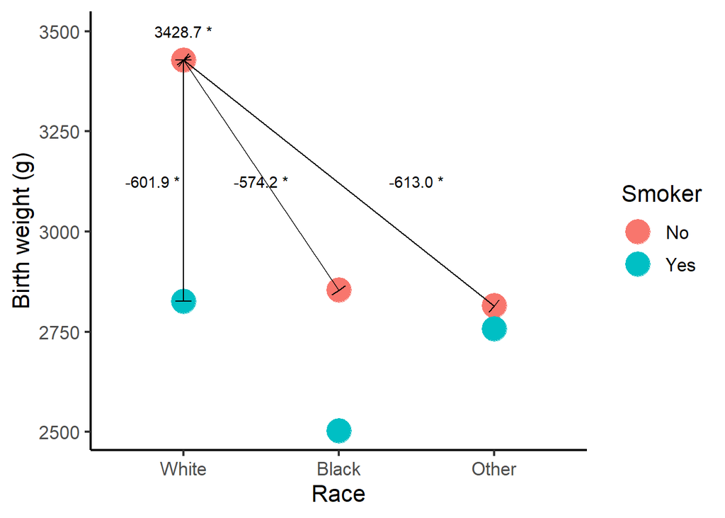

```r
library(grid)
ggplot(data = bwt_sum,
       aes(x = race,
           y = meanbwt,
           group = smoke,
           color = smoke)) +
  geom_point(size = 8) +
  labs(x = "Race",
       y = "Birth weight (g)") +
  scale_x_discrete(labels=c("1" = "White",
                            "2" = "Black",
                            "3" = "Other")) +
  scale_color_discrete(name = "Smoker",
                       labels = c("No", "Yes")) +
  annotate("text", x = 1, y = 3500, label = "3428.7 *") +
  annotate("segment", x = 1, xend = 2, y = 3428, yend = 2854,
           arrow = arrow(ends = "both", angle = 90, length = unit(.2,"cm"))) +
  annotate("text", x = 1.5, y = 3125, label = "-574.2 *") +
  annotate("segment", x = 1, xend = 3, y = 3428, yend = 2815,
           arrow = arrow(ends = "both", angle = 90, length = unit(.2,"cm"))) +
  annotate("text", x = 2.5, y = 3125, label = "-613.0 *") +
  annotate("segment", x = 1, xend = 1, y = 2826, yend = 3428,
           arrow = arrow(ends = "both", angle = 90, length = unit(.2,"cm"))) +
  annotate("text", x = .8, y = 3125, label = "-601.9 *")
```

#### 5.3.2 Interaction effects

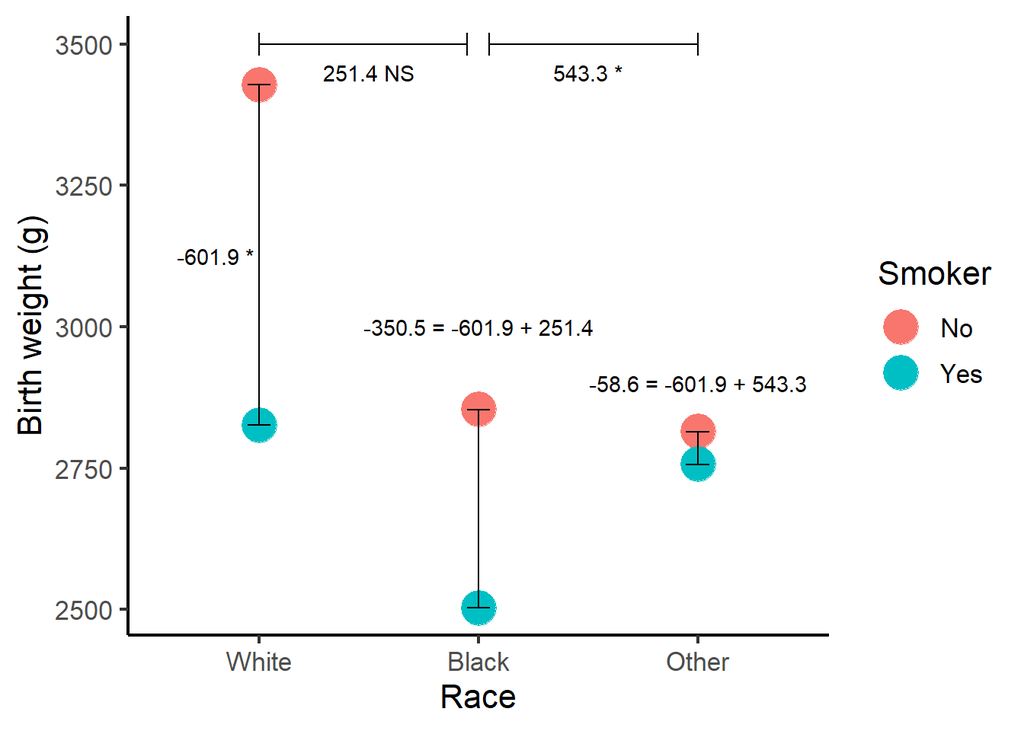

```r
library(grid)
ggplot(data = bwt_sum,
       aes(x = race,
           y = meanbwt,
           group = smoke,
           color = smoke)) +
  geom_point(size = 8) +
  labs(x = "Race",
       y = "Birth weight (g)") +
  scale_x_discrete(labels=c("1" = "White",
                            "2" = "Black",
                            "3" = "Other")) +
  scale_color_discrete(name = "Smoker",
                       labels = c("No", "Yes")) +
  annotate("segment", x = 1, xend = 1, y = 2826, yend = 3428,
           arrow = arrow(ends = "both", angle = 90, length = unit(.2,"cm"))) +
  annotate("text", x = .8, y = 3125, label = "-601.9 *") +

  annotate("segment", x = 2, xend = 2, y = 2854, yend = 2504,
           arrow = arrow(ends = "both", angle = 90, length = unit(.2,"cm"))) +
  annotate("text", x = 2, y = 3000, label = "-350.5 = -601.9 + 251.4") +

  annotate("segment", x = 3, xend = 3, y = 2815, yend = 2757,
           arrow = arrow(ends = "both", angle = 90, length = unit(.2,"cm"))) +
  annotate("text", x = 3, y = 2900, label = "-58.6 = -601.9 + 543.3") +

  annotate("segment", x = 1, xend = 1.95, y = 3500, yend = 3500,
           arrow = arrow(ends = "both", angle = 90, length = unit(.2,"cm"))) +
  annotate("text", x = 1.5, y = 3450, label = "251.4 NS") +

  annotate("segment", x = 2.05, xend = 3, y = 3500, yend = 3500,
           arrow = arrow(ends = "both", angle = 90, length = unit(.2,"cm"))) +
  annotate("text", x = 2.5, y = 3450, label = "543.3 *")
```

### 5.4 Reference: “black” and “nonsmoker”

```r
m1_black <- lm(bwt ~ white + other + smoker + white*smoker + other*smoker,
               data = birthwt)
summary(m1_black)
```

```
Call:
lm(formula = bwt ~ white + other + smoker + white * smoker +
    other * smoker, data = birthwt)

Residuals:
     Min       1Q   Median       3Q      Max
-2407.75  -416.50    31.25   462.50  1561.25

Coefficients:
             Estimate Std. Error t value Pr(>|t|)
(Intercept)   2854.50     170.91  16.702  < 2e-16 ***
white          574.25     199.58   2.877  0.00449 **
other          -38.72     194.19  -0.199  0.84218
smoker        -350.50     275.59  -1.272  0.20505
white:smoker  -251.40     309.13  -0.813  0.41712
other:smoker   291.88     351.27   0.831  0.40710
---
Signif. codes:  0 '***' 0.001 '**' 0.01 '*' 0.05 '.' 0.1 ' ' 1

Residual standard error: 683.6 on 183 degrees of freedom
Multiple R-squared:  0.1444,    Adjusted R-squared:  0.1211
F-statistic: 6.179 on 5 and 183 DF,  p-value: 2.562e-05
```

- Which means do each of the effects (coefficients) refer to?
  - Use the table of raw means as guide